# Story Teller data cleaning

Yaji Timothy

2023-06-17

## Load Required Packegs

```r
library(readr)
library(tidyverse)
```

## Read in Data

read in data from the working directory

```r
StoryData <- read_csv("StoryTellerData.csv", show_col_types = FALSE)
# Show first 4 row of the data
head(StoryData,4)
```

```
## # A tibble: 4 × 8
##   School Section VeryAheadby5 Middlingby0 Behindby1to5 MoreBehindby6to10
##   <chr>    <dbl>        <dbl>       <dbl>        <dbl>             <dbl>
## 1 A            1            0           5           54                 3
## 2 A            2            0           8           40                10
## 3 A            3            0           9           35                12
## 4 A            4            0          14           44                 5
## # ℹ 2 more variables: VeryBehindMoreThan11 <dbl>, Completed <dbl>
```

## Data Assessment for data Quality Issues

```r
glimpse(StoryData)
```

```
## Rows: 30
## Columns: 8
## $ School               <chr> "A", "A", "A", "A", "A", "A", "A", "A", "A", "A",…
## $ Section              <dbl> 1, 2, 3, 4, 5, 6, 7, 8, 9, 10, 11, 12, 13, 1, 2, …
## $ VeryAheadby5         <dbl> 0, 0, 0, 0, 0, 0, 0, 0, 0, 0, 0, 0, 0, 0, 0, 0, 0…
## $ Middlingby0          <dbl> 5, 8, 9, 14, 9, 7, 19, 3, 6, 13, 8, 2, 10, 4, 5, …
## $ Behindby1to5         <dbl> 54, 40, 35, 44, 42, 29, 22, 37, 29, 40, 32, 16, 3…
## $ MoreBehindby6to10    <dbl> 3, 10, 12, 5, 2, 3, 5, 11, 8, 5, 4, 2, 3, 0, 2, 1…
## $ VeryBehindMoreThan11 <dbl> 9, 16, 13, 12, 24, 10, 14, 18, 12, 5, 10, 3, 8, 6…
## $ Completed            <dbl> 10, 6, 11, 10, 8, 9, 19, 5, 10, 20, 15, 14, 5, 7,…
```

Visually assessing the data we see that the data is not in tidy form and section are not in the correct data types. We have to examine further programmatically to see if their there are other issues like, missing values, duplicate values and outliers and fix them before proceeding with EDA.

### Check for missing values

```r
colSums(is.na(StoryData))
```

```
##               School              Section         VeryAheadby5
##                    0                    0                    0
##          Middlingby0         Behindby1to5    MoreBehindby6to10
##                    0                    0                    0
## VeryBehindMoreThan11            Completed
##                    0                    0
```

```r
cat("There are" ,sum(duplicated(StoryData)), " duplicates in the dataset")
```

```
## There are 0  duplicates in the dataset
```

### Check if there is outlayer effect

```r
StoryData %>% summary()
```

```
##     School             Section       VeryAheadby5  Middlingby0
##  Length:30          Min.   : 1.00   Min.   :0     Min.   : 2.00
##  Class :character   1st Qu.: 2.25   1st Qu.:0     1st Qu.: 4.25
##  Mode  :character   Median : 5.50   Median :0     Median : 7.50
##                     Mean   : 5.90   Mean   :0     Mean   : 7.40
##                     3rd Qu.: 9.00   3rd Qu.:0     3rd Qu.: 9.75
##                     Max.   :13.00   Max.   :0     Max.   :19.00
##   Behindby1to5   MoreBehindby6to10 VeryBehindMoreThan11   Completed
##  Min.   : 4.00   Min.   : 0.000    Min.   : 0.000       Min.   : 1.00
##  1st Qu.:15.25   1st Qu.: 1.000    1st Qu.: 1.250       1st Qu.: 6.00
##  Median :22.00   Median : 2.000    Median : 5.500       Median :10.00
##  Mean   :25.13   Mean   : 3.333    Mean   : 6.967       Mean   :10.53
##  3rd Qu.:34.25   3rd Qu.: 4.750    3rd Qu.:11.500       3rd Qu.:14.00
##  Max.   :56.00   Max.   :12.000    Max.   :24.000       Max.   :27.00
```

From the output looking at that the mean and median are pretty close for all the variables which is an indication that no serious out-layer effect in the.

## Handle Issue issues found in the data

Next, after checking for all data issues, we will handle the issues found in the data which is the data not in tidy format. we will handle this by combining all columns except “Section” and”School” into two new column i.e. learncategory as factor, and NumberOfStudents as numeric

```r
#put the data in tidy format using pivot_long() function
story_long<-pivot_longer(StoryData, col= -c(School,Section),names_to = "learnCategory", values_to = "NumberOfStudents")%>%
  #convert leanrCatory to  data type to factor

mutate(across(c(learnCategory,Section), as_factor)) %>%
  #use the jenitor package to clean the names
  janitor::clean_names()
# View the properties of the data
glimpse((story_long))
```

```
## Rows: 180
## Columns: 4
## $ school             <chr> "A", "A", "A", "A", "A", "A", "A", "A", "A", "A", "…
## $ section            <fct> 1, 1, 1, 1, 1, 1, 2, 2, 2, 2, 2, 2, 3, 3, 3, 3, 3, …
## $ learn_category     <fct> VeryAheadby5, Middlingby0, Behindby1to5, MoreBehind…
## $ number_of_students <dbl> 0, 5, 54, 3, 9, 10, 0, 8, 40, 10, 16, 6, 0, 9, 35, …
```

We can see now that the data has 180 row with 4 columns with all tidy rule met. In the next section we will perform analysis with the data.

## Exploratory data analysis

*Which learn category has the highest median number of student*

[figure not shown]

```r
story_long%>%
  ggplot(aes(x=reorder(learn_category,number_of_students, median), y=number_of_students), colour=school )+
  geom_boxplot(fill = "purple", colour = "#3002FF", outlier.colour = "red")+
  labs(title = "Distribution of students and thier study time", x="Total number of students", y="study category", caption = "Fig 1.0, mean values is represented in darkgreen while, outlayers are in red")+
  #cutomize the look of the graph
  theme(plot.title = element_text(face = "bold", colour = "orange"),
        plot.caption =element_text(size = 8, face="italic", colour ="chocolate2" ),
        axis.text = element_text(colour = "blue "),
        )+
  coord_flip()+
 #add points for mean value on the plot
   stat_summary(fun=mean, colour="darkgreen", geom="point", size=2)
```

From the plot above, students who learn behind by 1 to 5 lesson has the highest median value and the greater interQuartile range.

*Which school contributors more to this highest median value?*

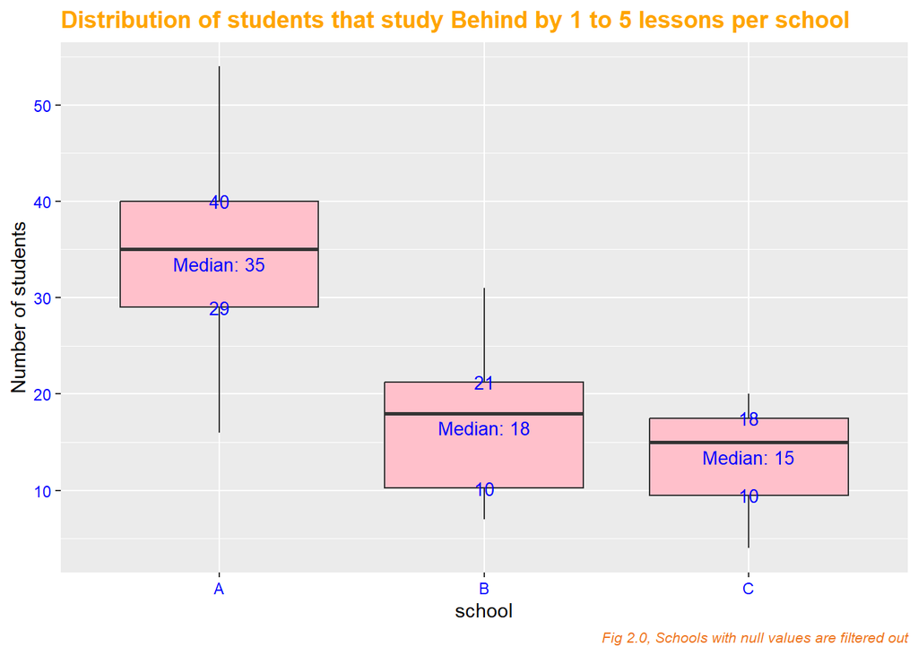

```r
story_long%>%
  filter(learn_category=="Behindby1to5"& (school %in% (c("A","B","C"))))%>%
  ggplot(aes(school, number_of_students))+
  geom_boxplot(fill="pink",show.legend = FALSE)+
  stat_summary(fun = median, geom = "text", col = "blue", size=3.5,    # Add text to plot
               vjust =1.5 , aes(label = paste("Median:", round(..y.., digits = 1))))+
   stat_summary(
    aes(y = stage(number_of_students, after_stat = quarts), label = round(after_stat(quarts),0)),
    geom = "text",col = "blue" ,size=3.5,
    fun.data = ~ data.frame(quarts = quantile(.x, probs = c(.25, .75)))
  )+
  labs(title = "Distribution of students that study Behind by 1 to 5 lessons per school",  y="Number of students", caption = "Fig 2.0, Schools with null values are filtered out")+
  theme(plot.title = element_text(face = "bold", colour = "orange"),
        plot.caption =element_text(size = 8, face="italic", colour ="chocolate2" ),
        axis.text = element_text(colour = "blue "))
```

From above plot, School A is the highest contributor to the number of students that study behind 1-5 lessons.